# Maching Learning Adult

Beichen Su

5/23/2017

# 1.Introduction

The data source is found on UCI Machine Learning data sets, called Adult: http://archive.ics.uci.edu/ml/machine-learning-databases/adult/

Prediction task is to determine whether a person makes over 50K a year.

Below gives the attributes:

> 50K, <=50K.

age: continuous.

workclass: Private, Self-emp-not-inc, Self-emp-inc, Federal-gov, Local-gov, State-gov, Without-pay, Never-worked.

fnlwgt: continuous.

education: Bachelors, Some-college, 11th, HS-grad, Prof-school, Assoc-acdm, Assoc-voc, 9th, 7th-8th, 12th, Masters, 1st-4th, 10th, Doctorate, 5th-6th, Preschool.

education-num: continuous.

marital-status: Married-civ-spouse, Divorced, Never-married, Separated, Widowed, Married-spouse-absent, Married-AF-spouse.

occupation: Tech-support, Craft-repair, Other-service, Sales, Exec-managerial, Prof-specialty, Handlers-cleaners, Machine-op-inspct, Adm-clerical, Farming-fishing, Transport-moving, Priv-house-serv, Protective-serv, Armed-Forces.

relationship: Wife, Own-child, Husband, Not-in-family, Other-relative, Unmarried.

race: White, Asian-Pac-Islander, Amer-Indian-Eskimo, Other, Black.

sex: Female, Male.

capital-gain: continuous.

capital-loss: continuous.

hours-per-week: continuous.

native-country: United-States, Cambodia, England, Puerto-Rico, Canada, Germany, Outlying-US(Guam-USVI-etc), India, Japan, Greece, South, China, Cuba, Iran, Honduras, Philippines, Italy, Poland, Jamaica, Vietnam, Mexico, Portugal, Ireland, France, Dominican-Republic, Laos, Ecuador, Taiwan, Haiti, Columbia, Hungary, Guatemala, Nicaragua, Scotland, Thailand, Yugoslavia, El-Salvador, Trinadad&Tobago, Peru, Hong, Holand-Netherlands.

## Task: perform logistic regression, random forest and GBM to the data and make prediction.

# 1.1 Data input

The Data contains a train and test set, but has missing value involved. So I combine the data, give it column names and delete missing values.

Take a look at the income, take <=50k as 0 and >50k for 1.

Factor out the categorical data

```r
setwd("~/Documents/STAT418/Stat 418/wk-05-ML/HW3")
library(readr)
data1 = read_csv("adult.csv", col_names = FALSE)
data2 = read_csv("adult_test.csv", col_names = FALSE)
originalData = rbind(data1,data2)
rm(data1,data2)
cols = c("age",
         "workclass",
         "fnlwgt",
         "education",
         "education_num",
         "marital_status",
         "occupation",
         "relationship",
         "race",
         "sex",
         "capital_gain",
         "capital_loss",
         "hours_per_week",
         "native_country",
         "income"
         )
colnames(originalData) = cols
# Detect missing value, there is no missing value marked as NA
# There are some ? in the workclass, occupation, native_country
sapply(originalData, function(x) sum(is.na(x)))
```

```
##            age      workclass         fnlwgt      education  education_num
##              0              0              0              0              0
## marital_status     occupation   relationship           race            sex
##              0              0              0              0              0
##   capital_gain   capital_loss hours_per_week native_country         income
##              0              0              0              0              0
```

```r
unique(originalData$workclass)
```

```
## [1] "State-gov"        "Self-emp-not-inc" "Private"
## [4] "Federal-gov"      "Local-gov"        "?"
## [7] "Self-emp-inc"     "Without-pay"      "Never-worked"
```

```r
unique(originalData$occupation)
```

```
##  [1] "Adm-clerical"      "Exec-managerial"   "Handlers-cleaners"
##  [4] "Prof-specialty"    "Other-service"     "Sales"
##  [7] "Craft-repair"      "Transport-moving"  "Farming-fishing"
## [10] "Machine-op-inspct" "Tech-support"      "?"
## [13] "Protective-serv"   "Armed-Forces"      "Priv-house-serv"
```

```r
unique(originalData$native_country)
```

```
##  [1] "United-States"              "Cuba"
##  [3] "Jamaica"                    "India"
##  [5] "?"                          "Mexico"
##  [7] "South"                      "Puerto-Rico"
##  [9] "Honduras"                   "England"
## [11] "Canada"                     "Germany"
## [13] "Iran"                       "Philippines"
## [15] "Italy"                      "Poland"
## [17] "Columbia"                   "Cambodia"
## [19] "Thailand"                   "Ecuador"
## [21] "Laos"                       "Taiwan"
## [23] "Haiti"                      "Portugal"
## [25] "Dominican-Republic"         "El-Salvador"
## [27] "France"                     "Guatemala"
## [29] "China"                      "Japan"
## [31] "Yugoslavia"                 "Peru"
## [33] "Outlying-US(Guam-USVI-etc)" "Scotland"
## [35] "Trinadad&Tobago"            "Greece"
## [37] "Nicaragua"                  "Vietnam"
## [39] "Hong"                       "Ireland"
## [41] "Hungary"                    "Holand-Netherlands"
```

```r
originalData = originalData[-which(originalData$workclass == "?"),]
originalData = originalData[-which(originalData$occupation == "?"),]
originalData = originalData[-which(originalData$native_country == "?"),]
# Take a look at the income, take <=50k as 0 and >50k for 1
unique(originalData$income)
```

```
## [1] "<=50K"  ">50K"   "<=50K." ">50K."
```

```r
index0 = which(originalData$income == "<=50K"| originalData$income == "<=50K.")
index1 = which(originalData$income == ">50K"| originalData$income == ">50K.")
length(index0)+length(index1) == nrow(originalData)
```

```
## [1] TRUE
```

```r
originalData$income[index0] = 0
originalData$income[index1] = 1
# Check the dimension of the data to fit the requirement of the data
table(originalData$income)
```

```
##
##     0     1
## 34014 11208
```

```r
dim(originalData)
```

```
## [1] 45222    15
```

```r
# Factor out the categorical data
factor_col = c("workclass",
         "education",
         "marital_status",
         "occupation",
         "relationship",
         "race",
         "sex",
         "native_country",
         "income"
         )
originalData[factor_col] = lapply(originalData[factor_col], factor)
write.csv(originalData, file = "mydata.csv", row.names = FALSE)
```

# 2. Machine Learning Models

## 2.1 Logistic regression

In this case I use cv.glmnet to the the cross validation to pick the best lambda for lasso regulation(alpha = 1), so that there’s no need to seperate the validation set.

### 2.1.1 Spliting data and sparse matrix

I choose to spilt the data 75% for train and 25% for test. Below I split the data and turn them into sparse matrix for glmnet.

```r
library(Matrix)
# Split the data
set.seed(12)
trainSize = floor(0.75 * nrow(originalData))
trainInd = sample(seq_len(nrow(originalData)), size = trainSize)
trainSet = originalData[trainInd,]
testSet = originalData[-trainInd,]

X = Matrix::sparse.model.matrix(income~. -1, data = originalData)
X_train = X[trainInd,]
X_test = X[-trainInd,]
```

### 2.1.2 Cross Validation

Do the cross validation so pick the best lambda under lasso regulization.

```r
library(glmnet)
system.time({
  cv = cv.glmnet( X_train, trainSet$income,  lambda = seq(0,1,0.001), family = "binomial", alpha = 1)
})
```

```
##    user  system elapsed
##  40.675   3.868  45.919
```

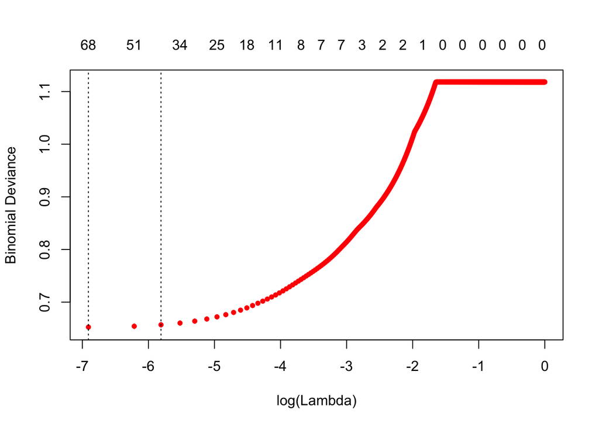

```r
plot(cv)
```

### 2.1.3 Build the train model

```r
model_logit = glmnet(X_train, trainSet$income,  lambda = 0, family = "binomial", alpha = 1, intercept = FALSE)
```

### 2.1.4 Performance of the model on local

Below I give the confusion table, auc and roc as the metric of goodness.

```r
pred = predict(model_logit, newx = X_test, type = "response")
# confusion table
tab = table(ifelse(pred > 0.5, 1,0), testSet$income)
tab
```

```
##
##        0    1
##   0 7865 1121
##   1  610 1710
```

```r
# missClassificationError
missClassificationError = 1 - sum(diag(tab))/sum(tab)
missClassificationError
```

```
## [1] 0.1531045
```

```r
# roc and auc
library(ROCR)
rocr_pred = prediction(pred, testSet$income)
# auc
auc = performance(rocr_pred, "auc")@y.values[[1]]
auc
```

```
## [1] 0.9054043
```

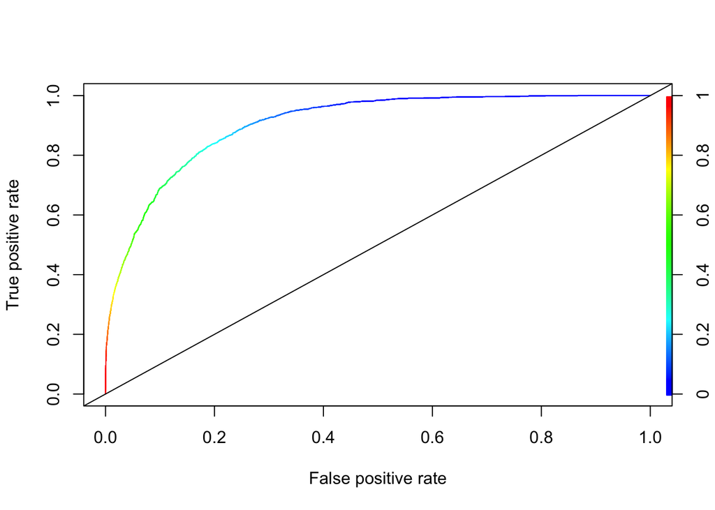

```r
# roc curve
roc = performance(rocr_pred,"tpr","fpr")
plot(roc, colorize=TRUE)
abline(a=0,b=1)
```

### 2.1.4 Performance of the model on h2o

```r
library(h2o)
h2o.init(nthreads=-1)
```

```
##  Connection successful!
##
## R is connected to the H2O cluster:
##     H2O cluster uptime:         13 days 15 hours
##     H2O cluster version:        3.10.4.6
##     H2O cluster version age:    27 days
##     H2O cluster name:           H2O_started_from_R_beichensu_szk262
##     H2O cluster total nodes:    1
##     H2O cluster total memory:   0.96 GB
##     H2O cluster total cores:    4
##     H2O cluster allowed cores:  2
##     H2O cluster healthy:        TRUE
##     H2O Connection ip:          localhost
##     H2O Connection port:        54321
##     H2O Connection proxy:       NA
##     H2O Internal Security:      FALSE
##     R Version:                  R version 3.4.0 (2017-04-21)
```

```r
dx = h2o.importFile("/Users/beichensu/Documents/STAT418/Stat 418/wk-05-ML/HW3/mydata.csv")
dx_split <- h2o.splitFrame(dx, ratios = 0.6, seed = 123)
dx_train <- dx_split[[1]]
dx_test <- dx_split[[2]]


Xnames <- names(dx_train)[which(names(dx_train)!="income")]

system.time({
  md <- h2o.glm(x = Xnames, y = "income", training_frame = dx_train,
                family = "binomial", alpha = 1, lambda_search = TRUE, nfolds = 5)
})
```

```
##    user  system elapsed
##   0.316   0.012  12.506
```

```r
md@model$lambda_best
```

```
## [1] 6.311638e-05
```

```r
h2o.auc(h2o.performance(md,dx_test))
```

```
## [1] 0.9076607
```

```r
md = h2o.glm(x = Xnames, y = "income", training_frame = dx_train,
                family = "binomial", alpha = 1, lambda = 0)
h2o.auc(h2o.performance(md, dx_test))
```

```
## [1] 0.9065739
```

This model gives auc at 0.906, a little bit better than glmnet.

## 2.2 Random Forest

Because there is no build in function for random forest to do cross validation, it’s important to split the data in to train, validation and test set. I split the data as 60% for train, 20% for validation and 20% for test. ### 2.2.1 Set up the data

```r
trainSize = floor(0.6*nrow(originalData))
trainInd = sample(1:nrow(originalData),trainSize)
trainSet = originalData[trainInd,]
NtrainSet = originalData[-trainInd,]
vSize = floor(0.5*nrow(NtrainSet))
vInd = sample(1:nrow(NtrainSet),vSize)
vSet = NtrainSet[vInd,]
testSet = NtrainSet[-vInd,]
```

### 2.2.2 Employ the validation set to find the optimal tree number

```r
library(randomForest)
```

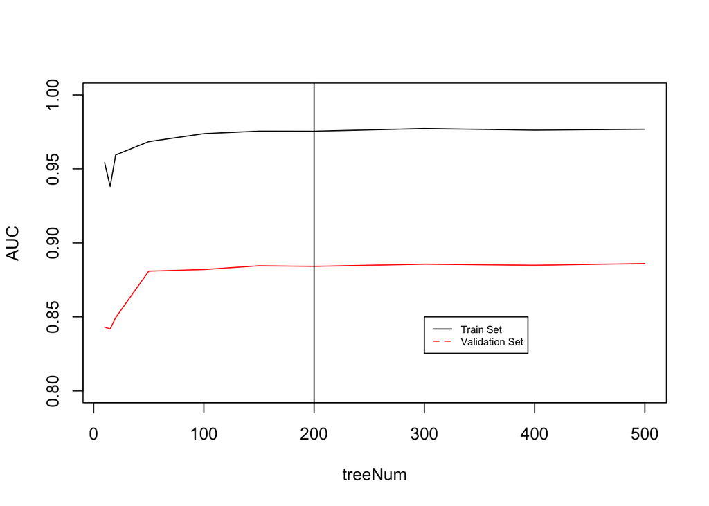

```r
treeNum = c(10,15,20,50,100,150,200,300,400,500)
aucV = c()
aucT = c()
for(i in 1 : length(treeNum)) {
  md = randomForest(income ~ ., data = trainSet, ntree = treeNum[i])
  tphat = predict(md, trainSet, type = "prob")[,"1"]
  trocr_obj = prediction(tphat, trainSet$income)
  vphat = predict(md, vSet, type = "prob")[,"1"]
  vrocr_obj = prediction(vphat, vSet$income)
  aucT[i] = performance(trocr_obj, "auc")@y.values[[1]]
  aucV[i] = performance(vrocr_obj, "auc")@y.values[[1]]
}
plot(treeNum, aucT,"l", ylim = c(0.8,1), ylab = "AUC")
points(treeNum,aucV, "l",col = "red")
legend(300,0.85,legend = c("Train Set", "Validation Set"), col = c("black","red"), lty = 1:2, cex = 0.6)
abline(v = 200)
```

As I employed the auc as the metric of the goodness of the model, it’s clear to see from the graph that after tree number increasing to 200, the AUC doesn’t really change. So I choose number of tree equal to 200 for my model.

### 2.2.3 Employ the validation set to find the number of column used in each split, keep number of tree equal to 200.

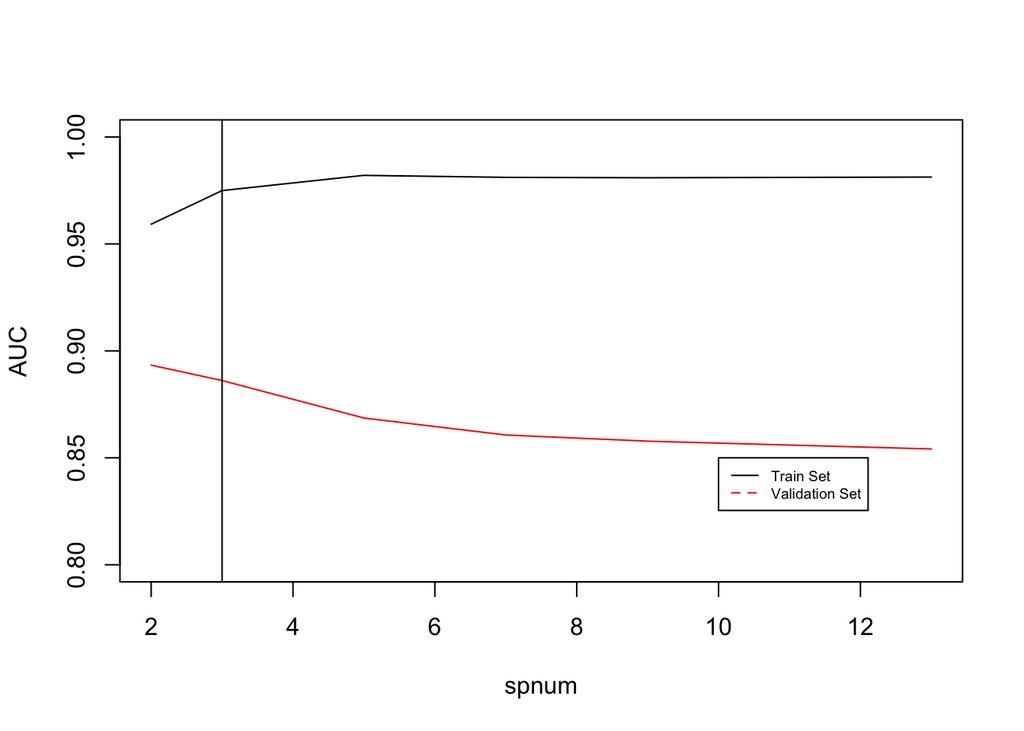

```r
spnum = c(2,3,5,7,9,13)
aucV = c()
aucT = c()
for(i in 1 : length(spnum)) {
  md = randomForest(income ~ ., data = trainSet, ntree = 200, mtry = spnum[i])
  tphat = predict(md, trainSet, type = "prob")[,"1"]
  trocr_obj = prediction(tphat, trainSet$income)
  vphat = predict(md, vSet, type = "prob")[,"1"]
  vrocr_obj = prediction(vphat, vSet$income)
  aucT[i] = performance(trocr_obj, "auc")@y.values[[1]]
  aucV[i] = performance(vrocr_obj, "auc")@y.values[[1]]
}
plot(spnum, aucT,"l", ylim = c(0.8,1), ylab = "AUC")
points(spnum,aucV, "l",col = "red")
legend(10,0.85,legend = c("Train Set", "Validation Set"), col = c("black","red"), lty = 1:2, cex = 0.6)
abline(v = 3)
```

As I employed the auc as the metric of the goodness of the model, it’s clear to see that if I increase the column used in each split, the prediction is getting better for my train set but worse on my validation set. It overfits the model as the number of column used. So I choose mtry = 3 for the column used at each split.

### 2.2.4 Employ the validation set to find optimal depth, keep number of tree equal to 200 and metry = 3.

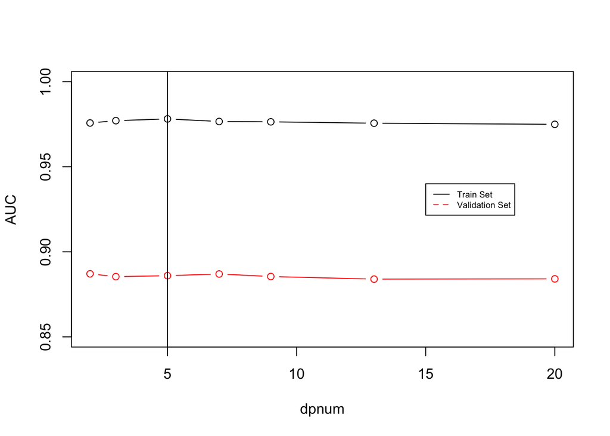

```r
dpnum = c(2,3,5,7,9,13,20)
aucV = c()
aucT = c()
for(i in 1 : length(dpnum)) {
  md = randomForest(income ~ ., data = trainSet, ntree = 200, mtry = 3, depth = dpnum[i])
  tphat = predict(md, trainSet, type = "prob")[,"1"]
  trocr_obj = prediction(tphat, trainSet$income)
  vphat = predict(md, vSet, type = "prob")[,"1"]
  vrocr_obj = prediction(vphat, vSet$income)
  aucT[i] = performance(trocr_obj, "auc")@y.values[[1]]
  aucV[i] = performance(vrocr_obj, "auc")@y.values[[1]]
}
plot(dpnum, aucT,"b", ylim = c(0.85,1), ylab = "AUC")
points(dpnum,aucV, "b",col = "red")
legend(15,0.94,legend = c("Train Set", "Validation Set"), col = c("black","red"), lty = 1:2, cex = 0.6)
abline(v = 5)
```

```r
model_RF = randomForest(income ~ ., data = trainSet, ntree = 200, mtry = 3, depth = 5)
testphat = predict(md, testSet, type = "prob")[,"1"]
test_obj = prediction(testphat, testSet$income)
aucTest = performance(test_obj, "auc")@y.values[[1]]
aucTest
```

```
## [1] 0.8840262
```

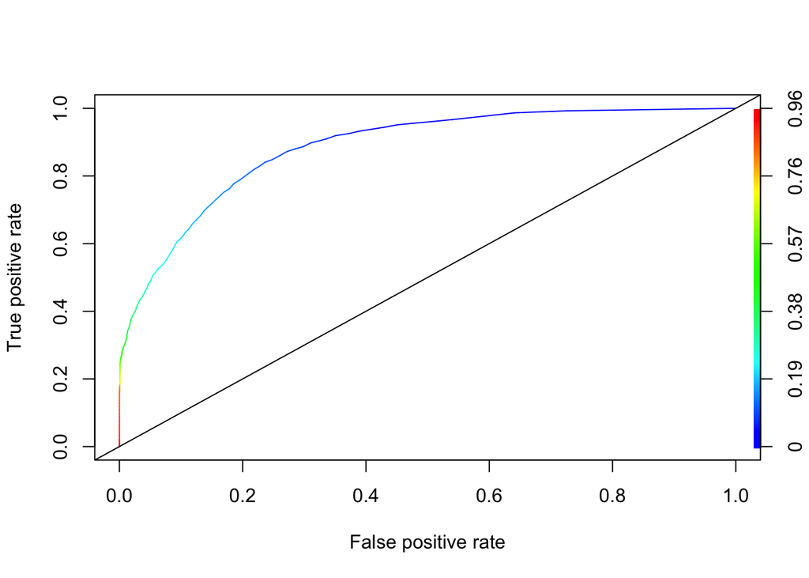

```r
roc = performance(test_obj,"tpr","fpr")
plot(roc, colorize=TRUE)
abline(a=0,b=1)
```

### 2.2.6 Random forest on h2o

For this random forest model on h2o I will employ a validation set and early stopping for time saving and avoiding overfitting.

```r
dx$income = h2o.asfactor(dx$income)
dx_split = h2o.splitFrame(dx, ratios = 0.6, seed = 12)
dx_train = dx_split[[1]]
dx_Ntrain = dx_split[[2]]
dx_split2 = h2o.splitFrame(dx_Ntrain, ratios = 0.5, seed = 12)
dx_test = dx_split2[[1]]
dx_valid = dx_split2[[2]]
system.time({
  md <- h2o.randomForest(x = Xnames, y = "income", training_frame = dx_train,
                         validation_frame = dx_valid, stopping_metric = "AUC",
                         stopping_rounds = 5, stopping_tolerance = 0.001, ntrees = 500)
})
```

```
##    user  system elapsed
##   0.563   0.301  47.598
```

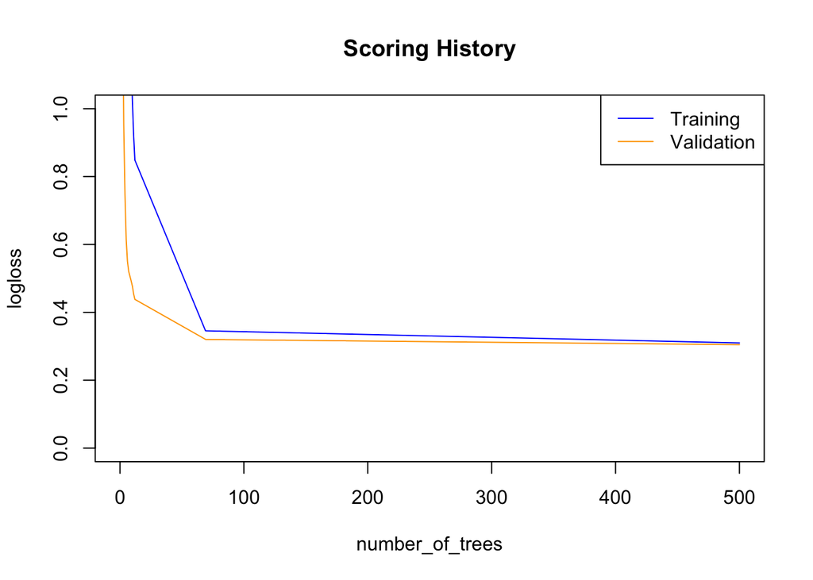

```r
plot(md)
```

```r
h2o.auc(h2o.performance(md,dx_test))
```

```
## [1] 0.9148666
```

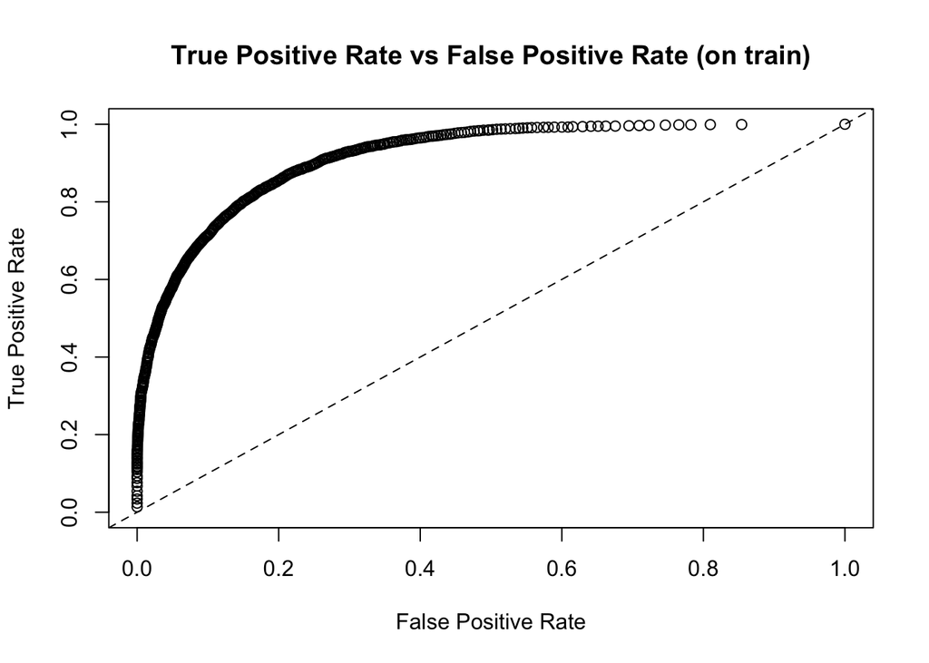

```r
plot(h2o.performance(md))
```

As the plot suggests, 100 trees should be enough to avoid over-training. And the auc at 0.9148 is quite nice.

## 2.3 GBM

### 2.3.1 Data input and subset

As there is a build in function to do the cross validation and model selection feature, I don’t split a validation set. As the dependent variable only takes numeric input, I turn the income to numeric.

```r
# without h2o
library(gbm)
set.seed(12)
originalData$income = as.numeric(originalData$income)
originalData$income = ifelse(originalData$income > 1, 1,0)
trainSize = floor(0.75 * nrow(originalData))
trainInd = sample(seq_len(nrow(originalData)), size = trainSize)
trainSet = originalData[trainInd,]
testSet = originalData[-trainInd,]
```

### 2.3.2 The optimal number of tree and tuning of learning ratio and depth.

I build a few gbm models based on its build-in validation algorithm. And the task is to find out the relationship between those parameters.

First I have a model with depth = 5 and learning ratio = 0.6

```
## Using cv method...
```

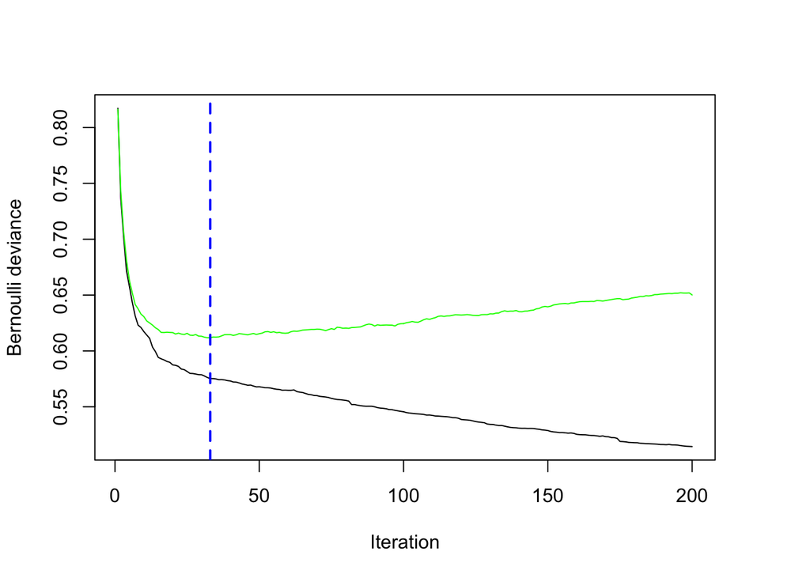

```
## [1] 33
```

```r
md = gbm(trainSet$income ~ ., data = trainSet, distribution = "bernoulli",
          n.trees = 200, interaction.depth = 5, shrinkage = 0.6, cv.folds = 5)
gbm.perf(md, plot.it = TRUE)
```

Now I tune the depth up to 10, and learning ratio as the same.

```
## Using cv method...
```

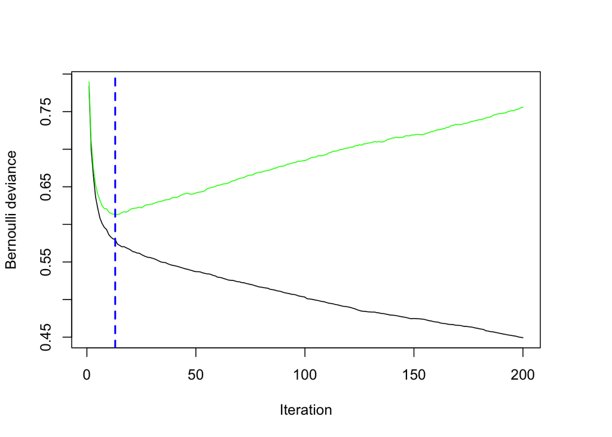

```
## [1] 13
```

```r
md = gbm(trainSet$income ~ ., data = trainSet, distribution = "bernoulli",
          n.trees = 200, interaction.depth = 10, shrinkage = 0.6, cv.folds = 5)
gbm.perf(md, plot.it = TRUE)
```

Below I keep the depth at 5 and tune the learning ratio down to 0.3.

```
## Using cv method...
```

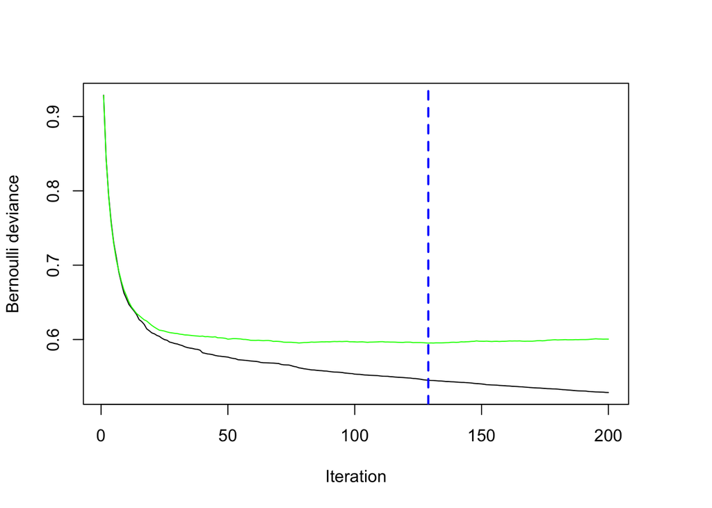

```
## [1] 129
```

```r
md = gbm(trainSet$income ~ ., data = trainSet, distribution = "bernoulli",
          n.trees = 200, interaction.depth = 5, shrinkage = 0.3, cv.folds = 5)
gbm.perf(md, plot.it = TRUE)
```

```r
model_GBM =  gbm(trainSet$income ~ ., data = trainSet, distribution = "bernoulli",
          n.trees = 105, interaction.depth = 5, shrinkage = 0.3)
```

### 2.3.3 Performance of the model on test set.

The confusion matrix, auc and roc curve

```r
pred = predict(model_GBM,testSet,n.trees = 105)
table(ifelse(pred>0,1,0), testSet$income)
```

```
##
##        0    1
##   0 7950 1006
##   1  525 1825
```

```r
rocr_pred = prediction(pred, testSet$income)
auc = performance(rocr_pred, "auc")
auc@y.values
```

```
## [[1]]
## [1] 0.9199884
```

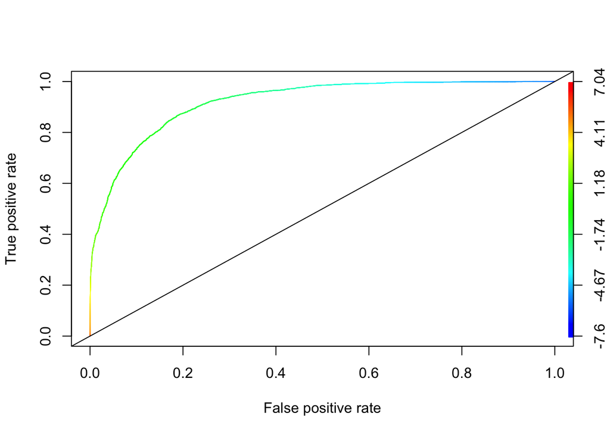

```r
roc = performance(rocr_pred,"tpr","fpr")
plot(roc, colorize = TRUE)
abline(a = 0, b = 1)
```

```r
table(ifelse(pred>0.-2,1,0), testSet$income)
```

```
##
##        0    1
##   0 6011  184
##   1 2464 2647
```

### 2.3.4 Explore the early stopping with h2o cluster.

TASK: use early stopping for determining the number of trees. Try also what happens if you don’t use early stopping and you overtrain (increasing the number of iterations/trees).

Write out the data used in last section and upload it to h2o. Split the train and test data set.

```r
dx = h2o.importFile("/Users/beichensu/Documents/STAT418/Stat 418/wk-05-ML/HW3/mydata.csv")
dx$income = h2o.asfactor(dx$income)
dx_split = h2o.splitFrame(dx, ratios = 0.6, seed = 12)
dx_train = dx_split[[1]]
dx_Ntrain = dx_split[[2]]
dx_split2 = h2o.splitFrame(dx_Ntrain, ratios = 0.5, seed = 12)
dx_test = dx_split2[[1]]
dx_valid = dx_split2[[2]]
```

Apply a GBM model without early stopping. Keep the learning rate at 0.3 and depth at 5, with large enough number of tree, 600.

```r
Xnames <- names(dx_train)[which(names(dx_train)!="income")]
time1 = system.time({
  md1 <- h2o.gbm(x = Xnames, y = "income", training_frame = dx_train, distribution = "bernoulli",
                ntrees = 600, max_depth = 5, learn_rate = 0.3, nbins = 100, seed = 12)
})
h2o.auc(h2o.performance(md1, dx_test))
```

```
## [1] 0.9207201
```

```r
time1
```

```
##    user  system elapsed
##   0.227   0.013  14.201
```

```r
md1
```

```
## Model Details:
## ==============
##
## H2OBinomialModel: gbm
## Model ID:  GBM_model_R_1494470107331_2848
## Model Summary:
##   number_of_trees number_of_internal_trees model_size_in_bytes min_depth
## 1             600                      600              726985         0
##   max_depth mean_depth min_leaves max_leaves mean_leaves
## 1         5    1.05000          1         32     6.16500
##
##
## H2OBinomialMetrics: gbm
## ** Reported on training data. **
##
## MSE:  0.06320026
## RMSE:  0.2513966
## LogLoss:  0.2056411
## Mean Per-Class Error:  0.1124808
## AUC:  0.9663975
## Gini:  0.9327951
##
## Confusion Matrix (vertical: actual; across: predicted) for F1-optimal threshold:
##            0    1    Error         Rate
## 0      19090 1358 0.066412  =1358/20448
## 1       1071 5684 0.158549   =1071/6755
## Totals 20161 7042 0.089292  =2429/27203
##
## Maximum Metrics: Maximum metrics at their respective thresholds
##                         metric threshold    value idx
## 1                       max f1  0.405148 0.823947 201
## 2                       max f2  0.225925 0.872783 267
## 3                 max f0point5  0.592979 0.852453 140
## 4                 max accuracy  0.465490 0.913612 180
## 5                max precision  0.999282 1.000000   0
## 6                   max recall  0.002978 1.000000 394
## 7              max specificity  0.999282 1.000000   0
## 8             max absolute_mcc  0.445396 0.766374 187
## 9   max min_per_class_accuracy  0.314093 0.897105 233
## 10 max mean_per_class_accuracy  0.280493 0.898582 245
##
## Gains/Lift Table: Extract with `h2o.gainsLift(<model>, <data>)` or `h2o.gainsLift(<model>, valid=<T/F>, xval=<T/F>)`
```

Now I employ the validation set to the model, use the AUC as the metric of stopping.

```r
time2 = system.time({
  md2 <- h2o.gbm(x = Xnames, y = "income", training_frame = dx_train,
                 validation_frame = dx_valid, distribution = "bernoulli",
                ntrees = 600, max_depth = 5, learn_rate = 0.5, nbins = 100, seed = 12,
                stopping_metric = "AUC", stopping_rounds = 3, stopping_tolerance = 0.001)
})
h2o.auc(h2o.performance(md2, dx_test))
```

```
## [1] 0.9231342
```

```r
time2
```

```
##    user  system elapsed
##   0.281   0.016   4.415
```

```r
md2
```

```
## Model Details:
## ==============
##
## H2OBinomialModel: gbm
## Model ID:  GBM_model_R_1494470107331_2908
## Model Summary:
##   number_of_trees number_of_internal_trees model_size_in_bytes min_depth
## 1              18                       18               26654         5
##   max_depth mean_depth min_leaves max_leaves mean_leaves
## 1         5    5.00000         18         31    26.55555
##
##
## H2OBinomialMetrics: gbm
## ** Reported on training data. **
##
## MSE:  0.08312942
## RMSE:  0.2883217
## LogLoss:  0.2639982
## Mean Per-Class Error:  0.1478007
## AUC:  0.9393874
## Gini:  0.8787747
##
## Confusion Matrix (vertical: actual; across: predicted) for F1-optimal threshold:
##            0    1    Error         Rate
## 0      18142 2306 0.112774  =2306/20448
## 1       1235 5520 0.182828   =1235/6755
## Totals 19377 7826 0.130169  =3541/27203
##
## Maximum Metrics: Maximum metrics at their respective thresholds
##                         metric threshold    value idx
## 1                       max f1  0.341626 0.757150 220
## 2                       max f2  0.187929 0.830341 281
## 3                 max f0point5  0.635221 0.788898 121
## 4                 max accuracy  0.497677 0.880381 165
## 5                max precision  0.995902 1.000000   0
## 6                   max recall  0.005215 1.000000 396
## 7              max specificity  0.995902 1.000000   0
## 8             max absolute_mcc  0.402527 0.673231 197
## 9   max min_per_class_accuracy  0.285427 0.857003 240
## 10 max mean_per_class_accuracy  0.248179 0.860315 256
```

[output cut: 17 more lines]

```
##
## Maximum Metrics: Maximum metrics at their respective thresholds
##                         metric threshold    value idx
## 1                       max f1  0.371444 0.728713 207
## 2                       max f2  0.127203 0.801972 309
## 3                 max f0point5  0.554244 0.758887 143
## 4                 max accuracy  0.528623 0.870424 151
## 5                max precision  0.995080 1.000000   0
## 6                   max recall  0.006619 1.000000 394
## 7              max specificity  0.995080 1.000000   0
## 8             max absolute_mcc  0.402444 0.638502 195
## 9   max min_per_class_accuracy  0.264254 0.838828 246
## 10 max mean_per_class_accuracy  0.239808 0.840775 256
##
## Gains/Lift Table: Extract with `h2o.gainsLift(<model>, <data>)` or `h2o.gainsLift(<model>, valid=<T/F>, xval=<T/F>)`
```

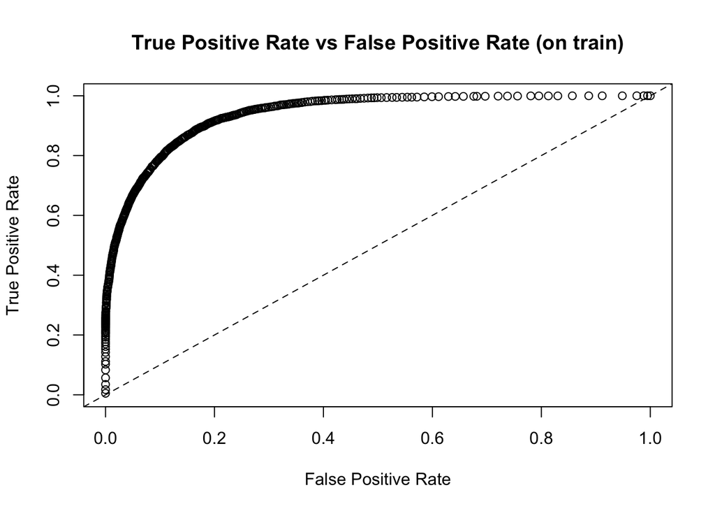

```r
plot(h2o.performance(md2))
```

With the validation set employed with early stopping option, the model only picked 18 trees and gave auc at 0.92313 with only 4.4 second.

It turns out the the early stopping is a great feature that employs the validation set to avoid overfitting. It will give higher auc, and takes less run time.

# Discussion

On local machine, using auc of the metric of the goodnees, random forest fits the worst among three, but on h2o, they are roughly the same with same parameter.

The auc of them is really high, all above 0.85, which means that as we are investigating the TPR and FPR, we do have a nice choice of cut off points to obtain high TPR and low FPR.

Aside those models, I feel that the predictors and the dependent variable in this data set are highly related so that we can gain a few machine learning model with high predictivity. As I tried on a show up vs no show up for medical appointment data set, the prediction is always bad, and the auc is even below 0.5, which shows me that those predictors such as height, weight and dicease type don’t really affect they show up on their appointment or not. This makes sense in real life if I miss my appointment might becasuse I just forget about it, or I have to do something more important or the alarm doesn’t ring.

This comparision is educative that machine learning can’t do much on uncoorelated variables actually.